# Annika Rodriguez — Data Analytics Portfolio

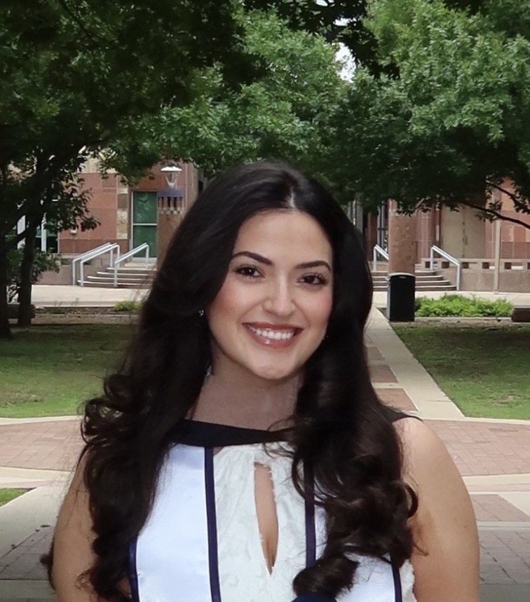

Annika Rodriguez

Data Analytics · Machine Learning · Business Intelligence

M.S. Data Analytics graduate (UTSA, 2026) with a BBA from Texas Tech, passionate about turning data into clear, actionable insights. Seeking opportunities to begin my career as an Analyst.

annikarodriguez02@gmail.com (210) 480-2121 linkedin.com/in/annika-rodriguez-

Open to opportunities

Willing to relocate

M.S. graduate, Aug 2026

7

Projects

10+

Tools

3

Industries

2

Degrees

PythonLLM EvaluationANOVA

Open-Source vs. Closed-Source LLMs in Life Insurance Client Support

Built a 325-question benchmark (200 general life insurance, 125 USAA-specific) to test whether lightweight open-source LLMs can serve as secure, affordable alternatives to a closed-source model for customer support. Generated 1,300 responses from GPT-5 Nano, Phi-3 Mini, Qwen 2.5 1.5B, and TinyLlama (run locally via Ollama), scored them with an automated GPT-5 Mini judge on accuracy, completeness, safety, and professional referral, and validated the judge against human ratings.

Key findings: GPT-5 Nano led at 4.59/5 vs. 3.72 (Phi-3 Mini), 3.23 (Qwen), and 2.89 (TinyLlama) · One-way ANOVA F = 274.46, p < 0.001 · Open-source models kept strong safety and referral scores but lost accuracy on company-specific questions, pointing to RAG or fine-tuning before enterprise use.

Python · Ollama · OpenAI API · LLM-as-a-Judge · Weighted Cohen's κ · One-Way ANOVA · Tukey HSD

Group project (UTSA Data Analytics Practicum) — Team of four. The team developed the benchmark datasets, built the response-generation pipeline, designed the LLM-as-a-judge rubric, validated it against human annotations (weighted κ = 0.755 for accuracy, 0.679 for completeness), and ran the statistical analysis.

Research Poster

POSTER_USAA_DA_Practicum.pdf ↗

Final Report

USAA_REPORT_DA_6833.pdf ↗

RRandom ForestSMOTETableau

PFAS Groundwater Contamination Risk Prediction

Developed and evaluated machine learning models using 26,900 California groundwater observations to predict high-risk PFAS contamination. Compared baseline and advanced models using ROC/AUC, F1-score, sensitivity, and confusion matrices, and applied SMOTE to address severe class imbalance.

Best model: Random Forest · 0.9818 AUROC · ~93% sensitivity · Supported prioritization of high-risk wells for groundwater testing.

R · Random Forest · SVM · kNN · Logistic Regression · SMOTE · caret · pROC · ggplot2

Group project (UTSA) — My contributions: Trained and tuned Random Forest, SVM, and kNN models; implemented 5-fold cross-validation; compared model performance; performed ROC/AUC analysis; interpreted results; and authored the Statistical Learning Methods and Model Comparison sections of the final report.

Research Poster

PFAS_Groundwater_Contamination_Poster.pdf ↗

My Code (R Markdown)

PFAS_in_California_Groundwater.Rmd ↗

RRandom Forest0.982 AUC

Google Play Store Success Prediction

Merged Google Play Store app metadata with user review data (8,196 apps, 19 variables) to identify the factors associated with app success. Engineered sentiment, engagement, and pricing features, conducted hypothesis testing (t-test, ANOVA, correlation), and built machine learning classifiers to predict high-performing applications.

Best model: Random Forest · 94.8% accuracy · 0.982 AUC · Identified reviews, sentiment subjectivity, and ratings as the strongest predictors of app success.

R · Random Forest · Logistic Regression · ggplot2 · corrplot · dplyr · pROC

Solo project (UTSA) — Completed all data cleaning, preprocessing, feature engineering, exploratory data analysis, hypothesis testing, predictive modeling, model evaluation, visualization, and presentation independently.

Presentation Slides

What_Makes_an_App_Successful.pdf ↗

R Code (R Markdown)

GooglePlayApps.Rmd ↗

Full HTML Report

GooglePlayApps.html ↗

PythonDeep LearningTensorFlow

Movie Revenue Success Prediction (Deep Learning)

Built and compared a feedforward neural network against a logistic regression baseline to predict movie financial success using the TMDB 5000 Movie Dataset (~5,000 movies). Used pre-release features including budget, popularity, runtime, and vote average, with an 80/20 train-test split and standardized feature scaling.

Results: Neural network achieved 82.4% accuracy and 0.81 F1-score, outperforming the logistic regression baseline (80.2% accuracy) and demonstrating the value of nonlinear modeling for movie success prediction.

Python · TensorFlow/Keras · Scikit-learn · Pandas · NumPy · Google Colab

Group project (UTSA) — My Contributions: Feature standardization, baseline logistic regression implementation, feedforward neural network architecture and training, evaluation of the neural network using accuracy, precision, recall, and F1-score, comparison of neural network performance against the logistic regression baseline, and visualization of accuracy.

Presentation Slides

MovieSuccessPrediction.pdf ↗

My Code (Jupyter Notebook)

Annika_Cloud.ipynb ↗

RTableauggplot2

YouTube Trending: What Rises to the Top?

Analyzed U.S. YouTube Trending data to identify the content, engagement, and publishing patterns associated with trending videos. The project explored how factors such as content category, creator popularity, upload timing, and audience engagement influence a video's likelihood of appearing on the Trending page, providing insights into digital content performance and audience behavior.

Key Insights: Highest engagement occurred during evening publishing hours · weekday uploads appeared on the trending page more frequently than weekend uploads · feature engineering highlighted how publishing time and engagement metrics influence trending performance

R · tidyverse · ggplot2 · highcharter

Group project (UTSA) — My Contributions: Engineered custom features including title length and engagement rate, developed interactive visualizations analyzing engagement by publish hour and weekday, and interpreted temporal engagement patterns to identify when trending videos receive the highest audience interaction.

Presentation Slides

YoutubeTrending.pdf ↗

R Code (Quarto)

Project_R_Code.qmd ↗

Full HTML Report

Project_R_Code.html ↗

RLogistic Regression

Customer Acquisition Modeling

Built predictive models to identify customers most likely to be acquired using customer and company attributes. Performed exploratory data analysis, created an 80/20 train-test split, developed logistic regression models, engineered features by removing redundant predictors, and evaluated model performance using confusion matrices.

Business insight: Demonstrated that company characteristics can be used to identify likely acquisition targets and support more efficient marketing campaigns.

R · Logistic Regression · caret · ggplot2 · Excel

Group project (UTSA) — My contributions: Data preparation, exploratory data analysis, train/test split, logistic regression modeling, feature selection, model evaluation, and interpretation of results.

Case Study Report

Customer_Retention_Report.pdf ↗

R Code — Customer Retention

CustomerRetention.Rmd ↗

R Code — Final

Final_Code_.Rmd ↗

Rendered Output (HTML)

Final-Code-.html ↗

SPSSMultiple Linear RegressionSurvey Analysis

Dairy Queen Consumer Purchase Intention Analysis

Conducted multiple linear regression analysis on consumer survey data to identify factors influencing Dairy Queen customer purchase intentions. Tested marketing hypotheses related to pricing, menu diversity, and customer service to evaluate their impact on future purchasing behavior.

Key finding: Menu diversity was the only statistically significant predictor of purchase intention (p = 0.012), while pricing and customer service showed no significant relationship, providing actionable insights for marketing strategy.

SPSS · Multiple Linear Regression · Survey Analysis · Qualtrics · Excel

Group project (Texas Tech) — My contributions: designed and conducted the SPSS regression analysis, interpreted model summary, ANOVA, and coefficient outputs, evaluated all three research hypotheses, and wrote the hypothesis testing section of the final report.

Research Report

DairyQueenReport.pdf ↗

SPSS Output (PDF)

DairyQueenSPSSAnalysis.pdf ↗

SPSS Data File

DairyQueenSPSSAnalysis.spv ↗

Hi, I'm **Annika Rodriguez**, a recent graduate with an M.S. in Data Analytics from the University of Texas at San Antonio and bachelor's degrees in Management and Marketing from Texas Tech University.

I'm passionate about using data to solve real-world problems and uncover insights that help organizations make better decisions. Through academic and personal projects, I've worked with machine learning, statistical analysis, predictive modeling, and data visualization across marketing, environmental science, customer analytics, and digital platforms. I primarily use R, Python, SQL, Excel, and Tableau, and I enjoy transforming complex data into clear, actionable insights.

Outside of analytics, I enjoy reading, creative writing, long walks, swimming, and volunteering in my community. I believe curiosity, continuous learning, and helping others are just as important as technical skills, and I bring that mindset to every project I take on.

I'm currently seeking opportunities to begin my career as an Analyst, where I can continue learning, collaborate with talented teams, and use data to solve meaningful business problems.

Programming & Modeling

R90%

Python78%

SQL75%

SAS65%

SPSS70%

Visualization & BI

Tableau85%

Power BI60%

Excel85%

ML / AI Methods

Random Forest Logistic Regression Decision Trees SVM Neural Networks SMOTE Cross-validation Feature Engineering ROC/AUC Sentiment Analysis LLM Evaluation TensorFlow/Keras scikit-learn caret

May 2025 –  
June 2025

Marketing Management Beta Tester

Western Governors University · Remote

- Evaluated assessment data, workflows, and course structures for a newly developed Marketing Management curriculum, identifying operational gaps and inefficiencies
- Assessed usability, process flow, and alignment with learning objectives across course modules
- Delivered structured, data-informed feedback to faculty and development teams to guide curriculum refinement

Oct 2022 –  
May 2025

Manager

Chris Simple Homes · Ruidoso, NM & Lubbock, TX

- Managed daily operations across multiple properties including guest communication, booking coordination, and maintenance
- Analyzed pricing, occupancy, and booking data to drive revenue optimization and marketing strategy decisions
- Evaluated guest feedback and service outcomes to identify trends and improve customer satisfaction

Education

Aug 2026

M.S. Data Analytics

The University of Texas at San Antonio · College of AI, Cyber, and Computing

Dec 2024

BBA, Management & Marketing

Texas Tech University · Rawls College of Business

Email

annikarodriguez02@gmail.com

Phone

(210) 480-2121

LinkedIn

linkedin.com/in/annika-rodriguez-

Location

San Antonio, TX · Open to relocation

Completed M.S. in Data Analytics at UTSA (Aug 2026). Actively seeking full-time analyst roles and open to relocating anywhere.